# InfoViz Project 2 on Echo360 data

Vijay Kumar and Muhammad Rashid

12/10/2022

We have Echo360 data over several terms of 2022, and we’d like to see how many classes are offered in various terms.

```r
library(readr)
library(tidyr)
library(dplyr)
library(ggplot2)
library(lubridate)
```

First read the Echo360 data file in the R. Echo360 data contains the information of courses offered by Clarkson university in Spring, Spring Quarter, Summer, Summer Quarter, Winter Quarter of year 2022.

```r
Echo360_New <- read_csv("~/Vijay/Eco360/top-sections_10072022.xlsx - 2022 inactiver terms only top-sections_10072022.csv")
```

[output not shown]

```r
head(Echo360_New)
```

| Course...1 | Course...2 | Number | Section | Undergrad Grad Multi | Level | School | Dept | Mode | Component Type | CLR PRL Both | Instructor | Term...13 | Term...14 | Yr | Size: 1-24 25-49 50-99 100-150 | Registered Students | Active Students | Video Views | "Engagement/ Student (Divided by Active students)" | Video Views / Student | Student Activities / Student | Polling Responses / Student | Organization | Department | Engagement (All activities) | Student Activities | Poll Responses Total | questionResponseCount | slideDeckViewCount | … |
| --- | --- | --- | --- | --- | --- | --- | --- | --- | --- | --- | --- | --- | --- | --- | --- | --- | --- | --- | --- | --- | --- | --- | --- | --- | --- | --- | --- | --- | --- | --- |
| PT617A | PT617A | 617A | 1 | G | G | HSCI | PT | P | SEM | CLR | Olzenak McGuire, Dana | Spring 2022 | Spring | 2022 | 1-24 | 1 | 1 | 0 | 1.0 | 0.0 | 1.0 | 0.0 | Clarkson | NA | 1 | 1 | 0 | 0 | 1 | … |
| PA511 | PA | 511 | 1 | G | G | HSCI | PA | P | LEC | CLR | White, Dawn | Summer 2022 | Summer | 2022 | 25-49 | 27 | 27 | 0 | 3.9 | 0.0 | 0.0 | 3.9 | Clarkson | NA | 106 | 0 | 106 | 0 | 0 | … |
| PA501 | PA | 501 | 1 | G | G | HSCI | PA | P | LEC | CLR | White, Dawn | Spring 2022 | Spring | 2022 | 25-49 | 27 | 27 | 15 | 43.3 | 0.6 | 6.3 | 36.4 | Clarkson | NA | 1168 | 170 | 983 | 0 | 169 | … |
| BIE530 | BIE | 530 | 61 | G | G | ARTSC | BIE | OL | LEC | PRL | Penn, Ilene | Spring Quarter 2022 | Spring Quarter | 2022 | 1-24 | 5 | 2 | 2 | 1.0 | 1.0 | 0.0 | 0.0 | Clarkson | NA | 2 | 0 | 0 | 0 | 0 | … |
| BY482 | BY | 482 | 1 | U | 400 | ARTSC | BIO | P | LEC | CLR | Wallace, Kenneth | Spring 2022 | Spring | 2022 | 1-24 | 6 | 3 | 3 | 1.0 | 1.0 | 0.0 | 0.0 | Clarkson | NA | 3 | 0 | 0 | 0 | 0 | … |
| ES110 | ES | 110 | 3 | U | 100 | ENGR | SOE | P | LEC | CLR | Chapman, Elisabeth | Spring 2022 | Spring | 2022 | 1-24 | 3 | 1 | 1 | 1.0 | 1.0 | 0.0 | 0.0 | Clarkson | NA | 1 | 0 | 0 | 0 | 0 | … |

```r
Echo360_New<-Echo360_New%>%dplyr::rename(Class_Size=`Size:
1-24
25-49
50-99
100-150`)
Echo360_New<-Echo360_New%>%dplyr::rename(Type=`CLR
PRL
Both`)
Echo360_New$Class_Size<- factor(Echo360_New$Class_Size ,levels=c("1-24","25-49","50-99","100-"))
```

We are interested in visualization of multiple categorical variable from tabular data. We want to see how many courses are offered in each term in different class size and level of course such as 100 level, 200, 300, 400,and Graduate with course code 500+.

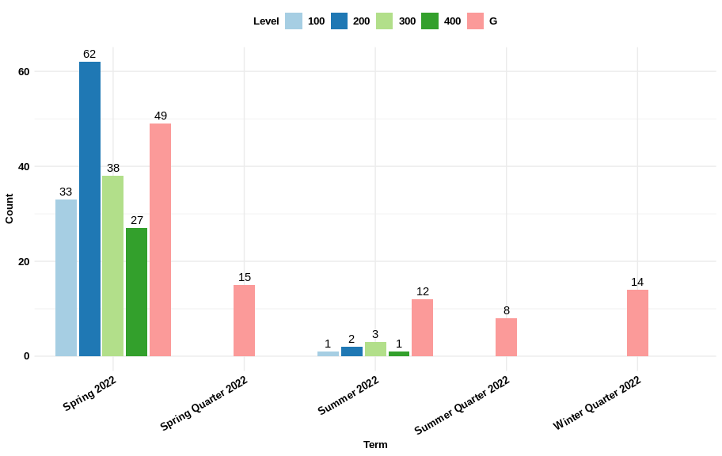

```r
ggplot(Echo360_New%>%dplyr::select(Term...13,Level)%>%drop_na(), aes(Term...13,..count..,fill=Level)) +
  geom_bar(aes(fill = Level), position=position_dodge2(preserve = "single"))+
  geom_text(aes(label=..count..),stat='count',position=position_dodge(0.9), vjust=-0.5)+
  theme_minimal()+
  scale_fill_brewer(palette="Paired")+
  labs(x="Term",y="Count")+
  theme(
    # LABLES APPEARANCE
    plot.title = element_text(size=10, face= "bold", colour= "black"),
    axis.title.x = element_text(size=10, face="bold", colour = "black"),
    axis.title.y = element_text(size=10, face="bold", colour = "black"),
    axis.text.x = element_text(size=10, face="bold", colour = "black",hjust = 1,angle = 30),
    axis.text.y = element_text(size=10, face="bold", colour = "black"),
    legend.text = element_text(size=10, face="bold", colour = "black"),
    legend.title  = element_text(size=10, face="bold", colour = "black"),
    #panel.grid.major = element_blank(), panel.grid.minor = element_blank(),
    legend.position = "top",
  )
```

The 200 level course with code 200 has more classes in Spring 2022, followed by graduate courses which have higher number of classes in all other terms. There are only graduate courses in all quarters.

The other way to plot this data using Mosaic plots but let me convert graduate course code G as 500, and treat it as quantitative variable and color the level by values.

```r
df<-Echo360_New %>% group_by(Term...13,Level) %>% summarise(cnt = n())
df$Level[df$Level == 'G'] <- '500'
df$Level<-as.numeric(df$Level)

df<-df%>%drop_na()
df
```

| Term...13 | Level | cnt |
| --- | --- | --- |
| Spring 2022 | 100 | 33 |
| Spring 2022 | 200 | 62 |
| Spring 2022 | 300 | 38 |
| Spring 2022 | 400 | 27 |
| Spring 2022 | 500 | 49 |
| Spring Quarter 2022 | 500 | 15 |
| Summer 2022 | 100 | 1 |
| Summer 2022 | 200 | 2 |
| Summer 2022 | 300 | 3 |
| Summer 2022 | 400 | 1 |

[output cut: 3 more lines]

```r
df<-Echo360_New %>% group_by(Term...13,Level) %>% summarise(cnt = n())
df$Level[df$Level == 'G'] <- '500'
df$Level<-as.numeric(df$Level)

df<-df%>%drop_na()
df
```

| Term...13 | Level | cnt |
| --- | --- | --- |
| Spring 2022 | 100 | 33 |
| Spring 2022 | 200 | 62 |
| Spring 2022 | 300 | 38 |
| Spring 2022 | 400 | 27 |
| Spring 2022 | 500 | 49 |
| Spring Quarter 2022 | 500 | 15 |
| Summer 2022 | 100 | 1 |
| Summer 2022 | 200 | 2 |
| Summer 2022 | 300 | 3 |
| Summer 2022 | 400 | 1 |

[output cut: 3 more lines]

```r
#summarize data

hc <- df %>%
  hchart(
    "treemap",
    hcaes(x = Term...13, value =cnt,color=Level)
  )
hc
```

[interactive chart not shown]

```r
NA
```

Lets plot them in Mosaic interactive plot where size of rectangle represent the number of classes. Its interactive plots, if we click on plot we can find total number of classes in each box with color as smaller to bigger level.

```r
df<-Echo360_New %>% group_by(Class_Size,Level) %>% summarise(cnt = n())
df$Level[df$Level == 'G'] <- '500'
df$Level<-as.numeric(df$Level)

df<-df%>%drop_na()
df
```

| Class_Size | Level | cnt |
| --- | --- | --- |
| 1-24 | 100 | 15 |
| 1-24 | 200 | 29 |
| 1-24 | 300 | 17 |
| 1-24 | 400 | 16 |
| 1-24 | 500 | 86 |
| 25-49 | 100 | 5 |
| 25-49 | 200 | 26 |
| 25-49 | 300 | 13 |
| 25-49 | 400 | 6 |
| 25-49 | 500 | 12 |

[output cut: 7 more lines]

```r
#summarize data

hc <- df %>%
  hchart(
    "treemap",
    hcaes(x = Class_Size, value =cnt,color=Level)
  )
hc
```

[interactive chart not shown]

```r
NA
```

There are more graduate classes in size 1-24, same as we have seen in bar plot.

There is another way to plot three categorical plot as Balloon plot

```r
df<-Echo360_New %>% group_by(Class_Size,Level,Term...13) %>% summarise(cnt = n())
df<-df%>%drop_na()
df
```

| Class_Size | Level | Term...13 | cnt |
| --- | --- | --- | --- |
| 1-24 | 100 | Spring 2022 | 14 |
| 1-24 | 100 | Summer 2022 | 1 |
| 1-24 | 200 | Spring 2022 | 27 |
| 1-24 | 200 | Summer 2022 | 2 |
| 1-24 | 300 | Spring 2022 | 15 |
| 1-24 | 300 | Summer 2022 | 2 |
| 1-24 | 400 | Spring 2022 | 15 |
| 1-24 | 400 | Summer 2022 | 1 |
| 1-24 | G | Spring 2022 | 43 |
| 1-24 | G | Spring Quarter 2022 | 13 |

[output cut: 20 more lines]

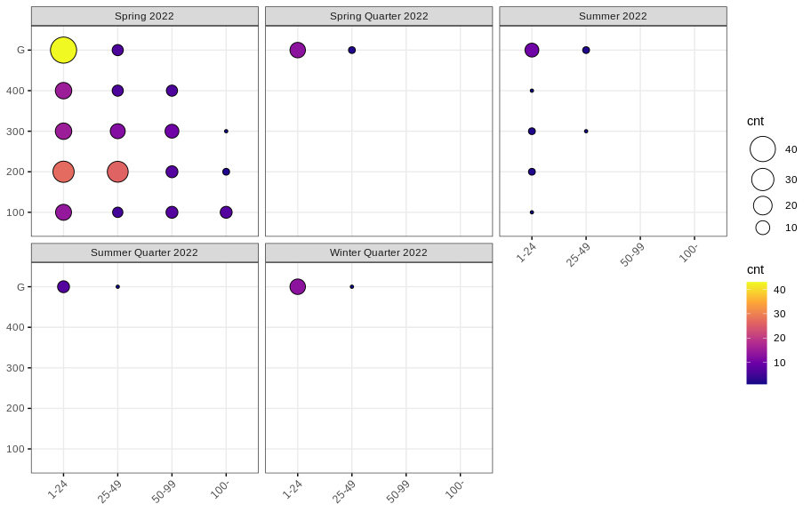

```r
ggballoonplot(df, x ="Class_Size" , y ="Level" , size = "cnt",
              fill = "cnt", facet.by = "Term...13",
              ggtheme = theme_bw()) +
  scale_fill_viridis_c(option = "C")
```

Its like correlation matrix in different panels. The x-axis represent one categorical variable (Class Size) and y represent second variable (Level of course) and panels represents third variable (Terms). For example Spring 2022, has many different sizes classes in all levels, i.e, G graduate level class with size of 1-24 have 40 classes offered in spring 2022 terms. However, other Terms have very few classes offered mainly graduadte in size 1-24 and 25-49.

The class sizes are categorical variables with size 1-24 to 100+ where size shows number of students

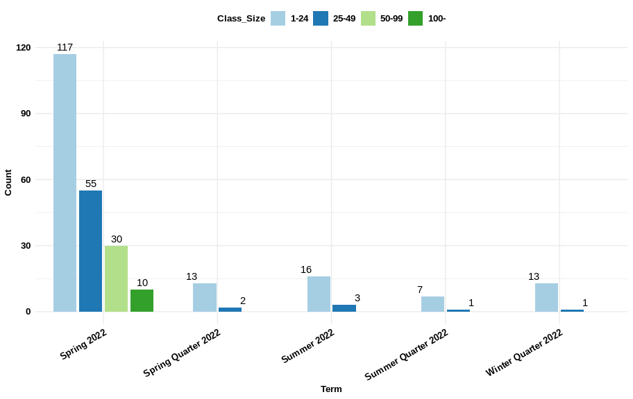

```r
ggplot(Echo360_New%>%dplyr::select(Term...13,Class_Size)%>%drop_na(), aes(Term...13,..count..,fill=Class_Size)) +
  geom_bar(aes(fill =Class_Size), position=position_dodge2(preserve = "single"))+
  geom_text(aes(label=..count..),stat='count',position=position_dodge(0.9), vjust=-0.5)+
  theme_minimal()+
  scale_fill_brewer(palette="Paired")+
  labs(x="Term",y="Count")+
  theme(
    # LABLES APPEARANCE
    plot.title = element_text(size=10, face= "bold", colour= "black"),
    axis.title.x = element_text(size=10, face="bold", colour = "black"),
    axis.title.y = element_text(size=10, face="bold", colour = "black"),
    axis.text.x = element_text(size=10, face="bold", colour = "black",hjust = 1,angle = 30),
    axis.text.y = element_text(size=10, face="bold", colour = "black"),
    legend.text = element_text(size=10, face="bold", colour = "black"),
    legend.title  = element_text(size=10, face="bold", colour = "black"),
    #panel.grid.major = element_blank(), panel.grid.minor = element_blank(),
    legend.position = "top",
  )
```

There are more classes of small size with 1-24 students in all terms, followed by bigger classes.

```r
#My example
#Echo360_New$Type[Echo360_New$Type == 'BOTH'] <- 'Both'
#Echo360_New$Type[Echo360_New$Type == 'both'] <- 'Both'
```

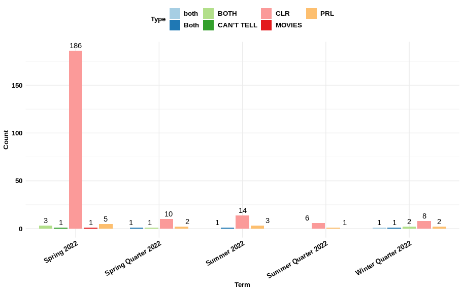

```r
ggplot(Echo360_New%>%dplyr::select(Term...13,Type)%>%drop_na(), aes(Term...13,..count..,fill=Type)) +
  geom_bar(aes(fill = Type), position=position_dodge2(preserve = "single"))+
  geom_text(aes(label=..count..),stat='count',position=position_dodge(0.9),vjust=-0.5)+
  theme_minimal()+
  scale_fill_brewer(palette="Paired")+
  labs(x="Term",y="Count")+
  theme(
    # LABLES APPEARANCE
    plot.title = element_text(size=10, face= "bold", colour= "black"),
    axis.title.x = element_text(size=10, face="bold", colour = "black"),
    axis.title.y = element_text(size=10, face="bold", colour = "black"),
    axis.text.x = element_text(size=10, face="bold", colour = "black",hjust = 1,angle = 30),
    axis.text.y = element_text(size=10, face="bold", colour = "black"),
    legend.text = element_text(size=10, face="bold", colour = "black"),
    legend.title  = element_text(size=10, face="bold", colour = "black"),
    #panel.grid.major = element_blank(), panel.grid.minor = element_blank(),
    legend.position = "top",
  )
```

There are more CLR mode classes are in all terms. Lets plot with class size

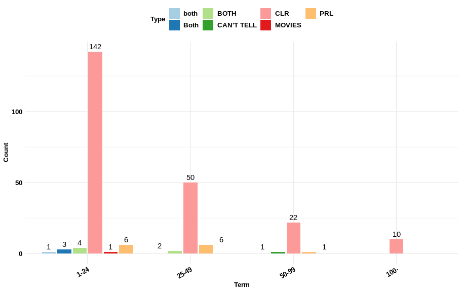

```r
ggplot(Echo360_New%>%dplyr::select(Class_Size,Type)%>%drop_na(), aes(Class_Size,..count..,fill=Type)) +
  geom_bar(aes(fill = Type), position=position_dodge2(preserve = "single"))+
  geom_text(aes(label=..count..),stat='count',position=position_dodge(0.9),vjust=-0.5)+
  theme_minimal()+
  scale_fill_brewer(palette="Paired")+
  labs(x="Term",y="Count")+
  theme(
    # LABLES APPEARANCE
    plot.title = element_text(size=10, face= "bold", colour= "black"),
    axis.title.x = element_text(size=10, face="bold", colour = "black"),
    axis.title.y = element_text(size=10, face="bold", colour = "black"),
    axis.text.x = element_text(size=10, face="bold", colour = "black",hjust = 1,angle = 30),
    axis.text.y = element_text(size=10, face="bold", colour = "black"),
    legend.text = element_text(size=10, face="bold", colour = "black"),
    legend.title  = element_text(size=10, face="bold", colour = "black"),
    #panel.grid.major = element_blank(), panel.grid.minor = element_blank(),
    legend.position = "top",
  )
```

No matter what size of class is there but again CLR mode classes are more.

We can plot same data differently as Mosaic plots or Baloon plot.

Conclusion: We have used three different ways to plot the two and three categorical variables, that includes multiple bar plots, mosaic plots and baloon plots. The all plots can tell similar story.